# Machine learning project: Classfication methods using R Samson Oni (soni5@umbc.edu) April 9, 2019

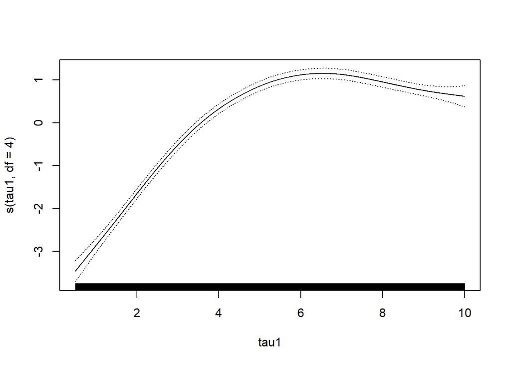

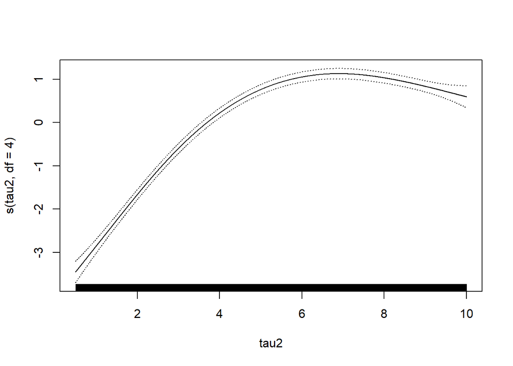

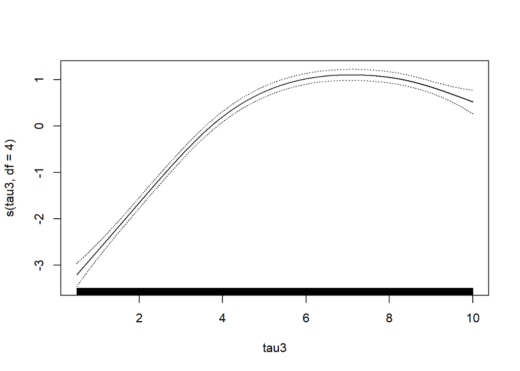

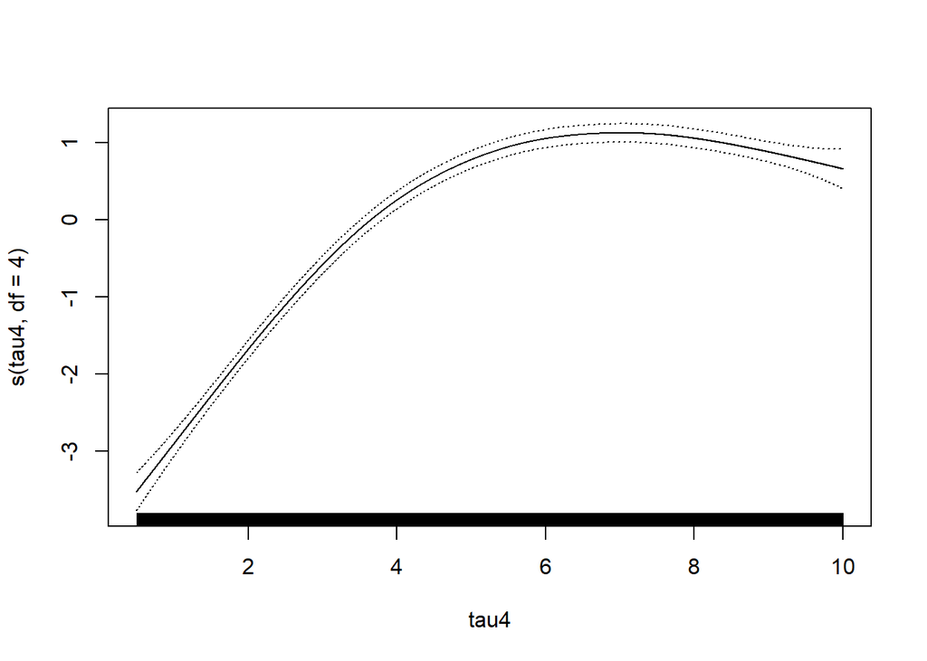

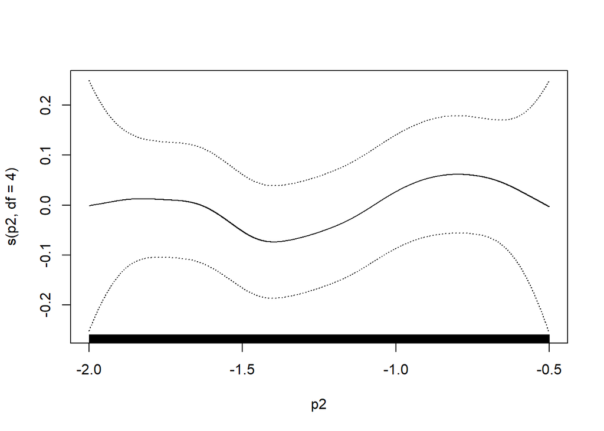

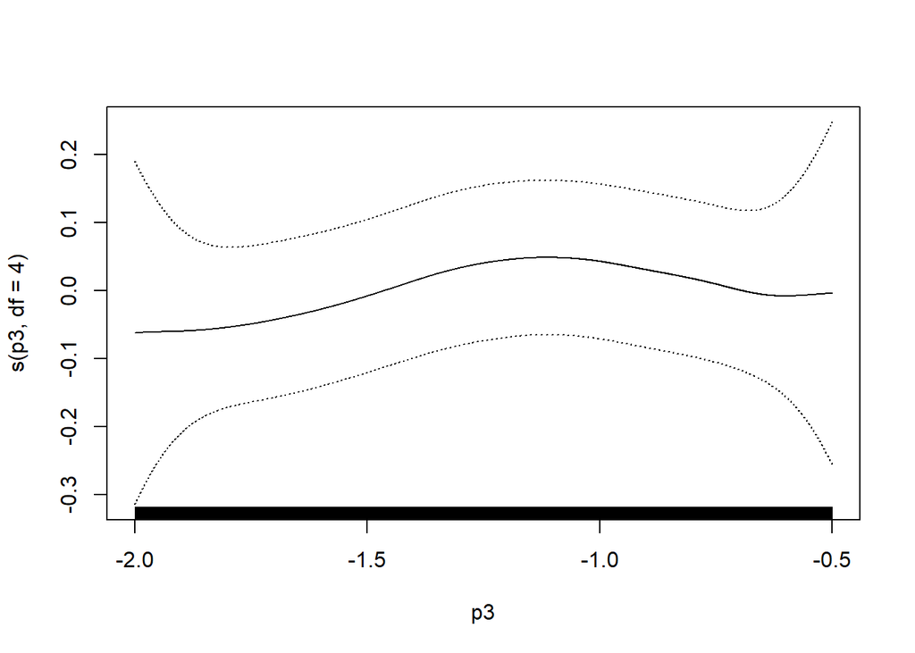

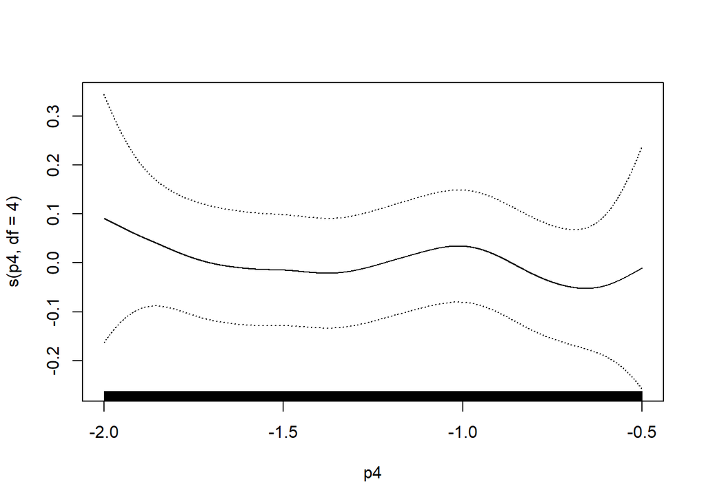

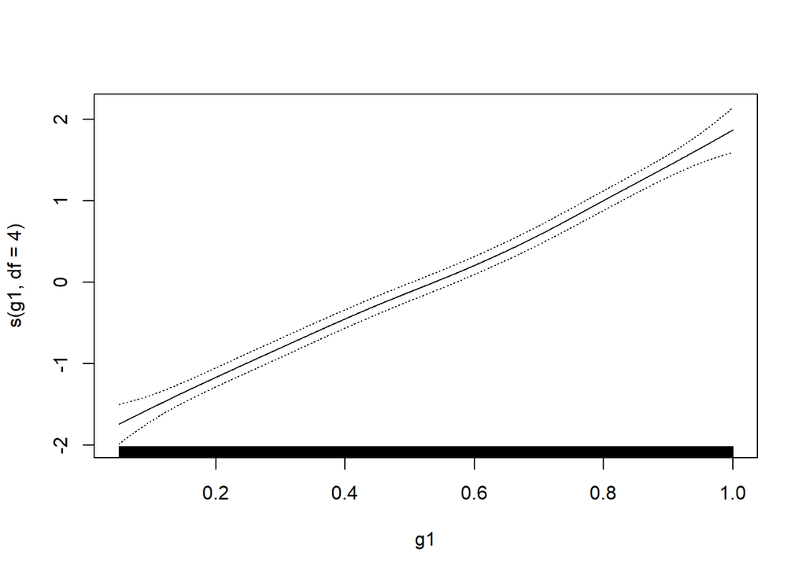

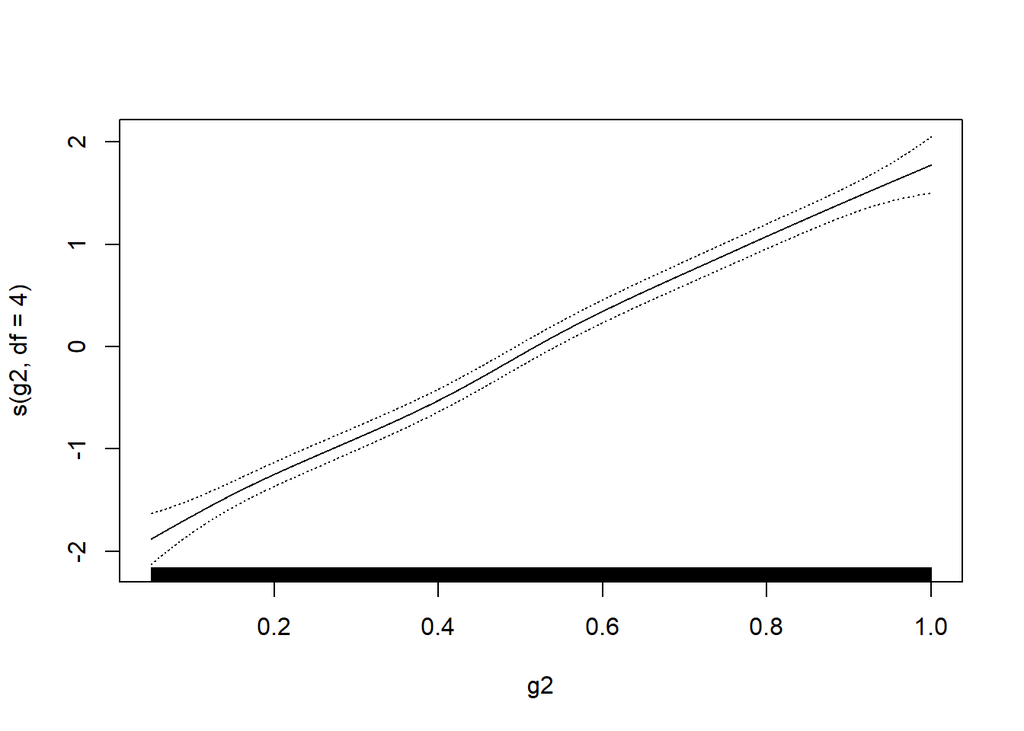

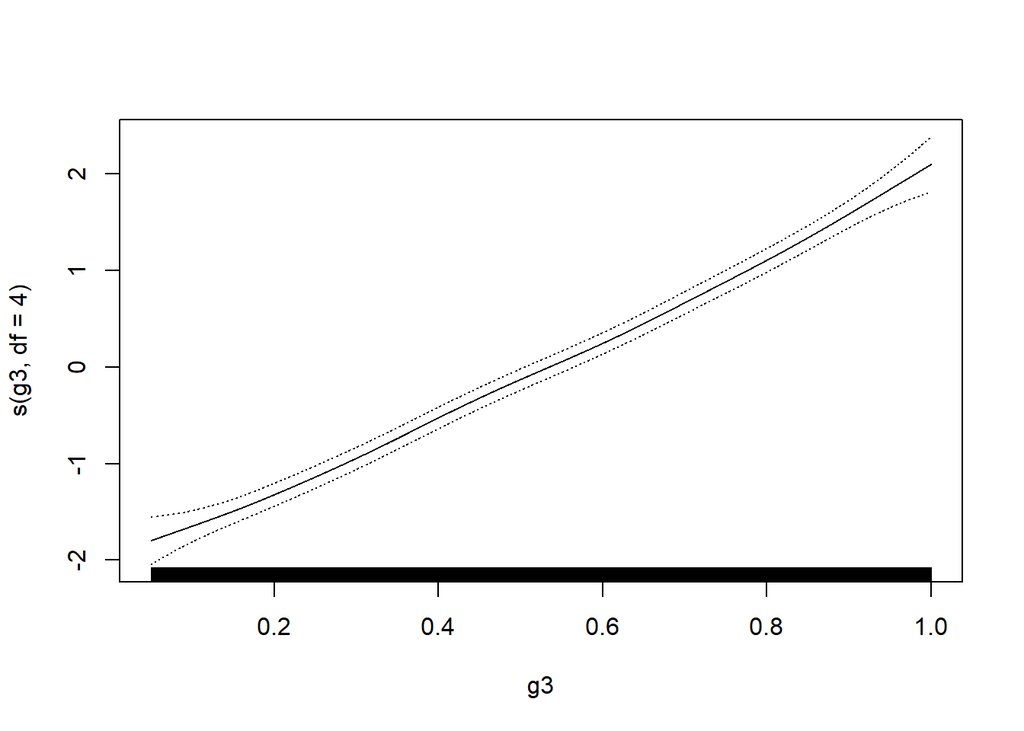

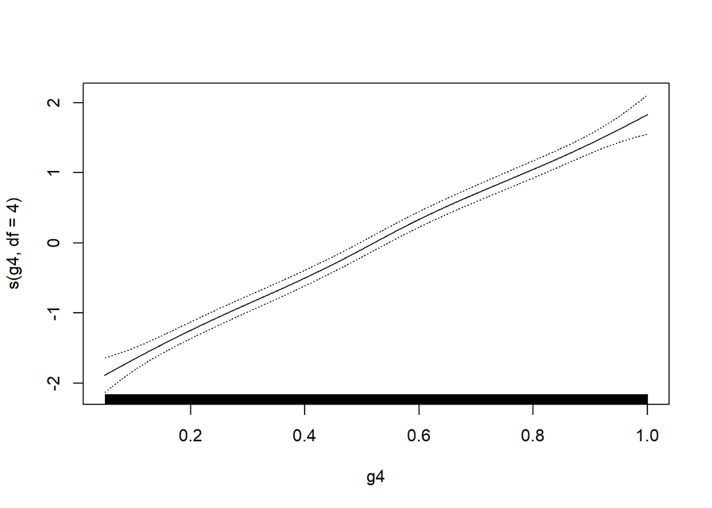

```r
#logistic Regression Model
logitgam1<-gam(I(stabf) ~ s(tau1,df=4) + s(tau2,df=4) + s(tau3,df=4) + s(tau4,df=4) + s(p2,df=4) +s(p3,df=4)+s(p4,df=4) + + s(g1,df=4) + s(g1,df=4) + s(g2,df=4) + s(g3,df=4) + s(g4,df=4) ,data=data,family=binomial)
plot(logitgam1,se=T)
```

From the above procedure, we can see that the non-linear fitted for p2,p3 and p4, is not significant for each of them.

# 5 Tree-Based methods

## 5.1 Fitting Classification Trees

The tree library is used to construct classification trees. I will use the electricity data to ilustarte this.

```r
library(tree)
tree.data=tree(stabf~.,data)
summary(tree.data)
```

```
##
## Classification tree:
## tree(formula = stabf ~ ., data = data)
## Variables actually used in tree construction:
## [1] "tau1" "g3"   "tau2" "g2"   "tau3" "tau4" "g1"
## Number of terminal nodes:  14
## Residual mean deviance:  0.9339 = 9326 / 9986
## Misclassification error rate: 0.2254 = 2254 / 10000
```

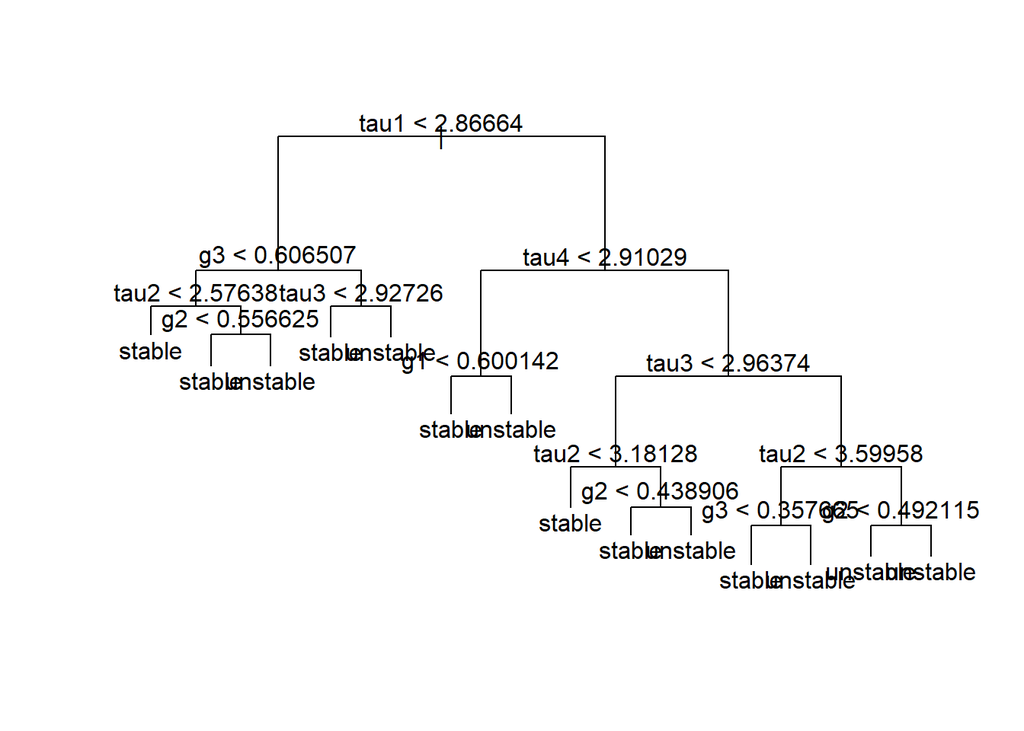

```r
plot(tree.data)
text(tree.data,pretty = 0)
```

I used plot() function to display the tree structure, and the text() function to disply the node labels. The argument pretty=0 is to include the category names of the qualitative predictors rather than displaying a letter for each category.

```r
tree.data
```

```
## node), split, n, deviance, yval, (yprob)
##       * denotes terminal node
##
##  1) root 10000 13090.0 unstable ( 0.36200 0.63800 )
##    2) tau1 < 2.86664 2491  3370.0 stable ( 0.59093 0.40907 )
##      4) g3 < 0.606507 1470  1780.0 stable ( 0.70612 0.29388 )
##        8) tau2 < 2.57638 344   147.0 stable ( 0.94477 0.05523 ) *
##        9) tau2 > 2.57638 1126  1480.0 stable ( 0.63321 0.36679 )
##         18) g2 < 0.556625 607   600.8 stable ( 0.80395 0.19605 ) *
##         19) g2 > 0.556625 519   710.3 unstable ( 0.43353 0.56647 ) *
##      5) g3 > 0.606507 1021  1392.0 unstable ( 0.42507 0.57493 )
##       10) tau3 < 2.92726 265   293.0 stable ( 0.75849 0.24151 ) *
##       11) tau3 > 2.92726 756   933.9 unstable ( 0.30820 0.69180 ) *
##    3) tau1 > 2.86664 7509  8990.0 unstable ( 0.28606 0.71394 )
##      6) tau4 < 2.91029 1911  2649.0 stable ( 0.50759 0.49241 )
##       12) g1 < 0.600142 1109  1443.0 stable ( 0.64472 0.35528 ) *
##       13) g1 > 0.600142 802  1003.0 unstable ( 0.31796 0.68204 ) *
##      7) tau4 > 2.91029 5598  5761.0 unstable ( 0.21043 0.78957 )
##       14) tau3 < 2.96374 1469  2002.0 unstable ( 0.42342 0.57658 )
##         28) tau2 < 3.18128 427   507.2 stable ( 0.71897 0.28103 ) *
##         29) tau2 > 3.18128 1042  1277.0 unstable ( 0.30230 0.69770 )
##           58) g2 < 0.438906 440   609.9 stable ( 0.50682 0.49318 ) *
##           59) g2 > 0.438906 602   514.8 unstable ( 0.15282 0.84718 ) *
##       15) tau3 > 2.96374 4129  3263.0 unstable ( 0.13466 0.86534 )
##         30) tau2 < 3.59958 1318  1559.0 unstable ( 0.27845 0.72155 )
##           60) g3 < 0.357665 420   578.4 stable ( 0.54762 0.45238 ) *
##           61) g3 > 0.357665 898   767.1 unstable ( 0.15256 0.84744 ) *
##         31) tau2 > 3.59958 2811  1385.0 unstable ( 0.06724 0.93276 )
##           62) g2 < 0.492115 1246   978.0 unstable ( 0.13323 0.86677 ) *
##           63) g2 > 0.492115 1565   239.8 unstable ( 0.01470 0.98530 ) *
```

Above procedure tree.data printed output corresponding tp each branch of the tree. Branches that lead to terminal nodes are indicated using asterisks. To evaluate the performance of the classification tree on the data, I estimate the test error.

```r
set.seed(2)
train=sample(1:nrow(data),7500)
data.test = data[-train,]
stabf.test = data$stabf[-train]
tree.data=tree(stabf~.,data,subset = train)
tree.pred=predict(tree.data,data.test,type = "class")
table(tree.pred,stabf.test)
```

```
##           stabf.test
## tree.pred  stable unstable
##   stable      663      271
##   unstable    269     1297
```

```r
(663+1297)/2500
```

```
## [1] 0.784
```

Next, I will carry out pruning the tree to see if there can be improvement on the tree.I use FUN=prune.misclass in order to indicate that we want the classiï¬cation error rate to guide the cross-validation and pruning process, rather than the default for the cv.tree() function, which is deviance.

```r
set.seed(3)
cv.data=cv.tree(tree.data,FUN=prune.misclass)
names(cv.data)
```

```
## [1] "size"   "dev"    "k"      "method"
```

```r
cv.data
```

```
## $size
## [1] 16 14 12 10  8  6  4  2  1
##
## $dev
## [1] 1738 1738 1752 1852 2002 2024 2210 2311 2688
##
## $k
## [1]  -Inf   0.0  12.0  37.0  68.0  73.0  94.5 112.0 324.0
##
## $method
## [1] "misclass"
##
## attr(,"class")
## [1] "prune"         "tree.sequence"
```

The above procedure outputs the number of terminal nodes of each tree considered(size), value of cost-complexity parameter used(k), corss-validation error(dev) and method which is misclass. Tree with 16 terminal nodes and tree with terminal nodes 14 results in the lowest cross-validation error rate, with 1738 cross-validation errors.

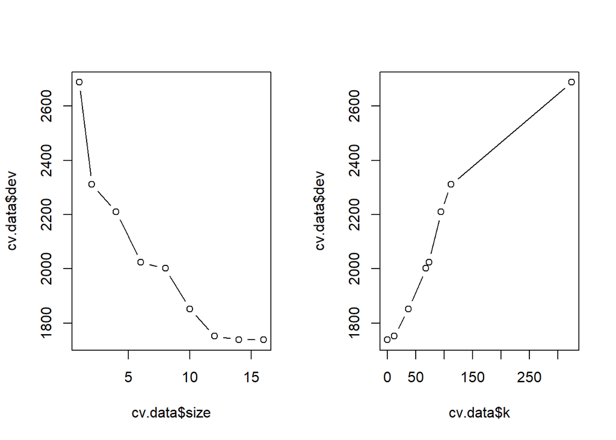

```r
par(mfrow=c(1,2))
plot(cv.data$size,cv.data$dev, type = "b")
plot(cv.data$k,cv.data$dev, type = "b")
```

Above is the plot of the error rate as function of both size and k.

To prune the tree, I will use the prune.misclass() function to obtain the 16-node tree.

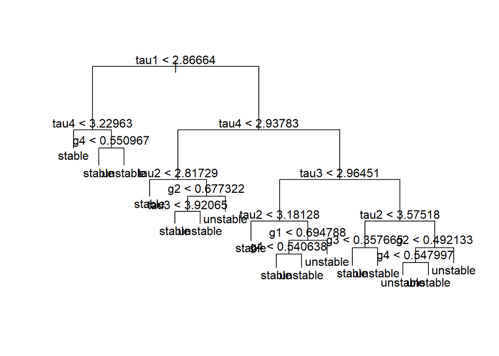

```r
prune.data=prune.misclass(tree.data,best = 16)
plot(prune.data)
text(prune.data,pretty=0)
```

To find out how well the pruned tree perform on the test data set, I will apply the predict() function.

```r
tree.pred=predict(prune.data,data.test,type = "class")
table(tree.pred,stabf.test)
```

```
##           stabf.test
## tree.pred  stable unstable
##   stable      663      271
##   unstable    269     1297
```

```r
(663+1297)/2500
```

```
## [1] 0.784
```

```r
#install.packages("randomForest")
library("randomForest")
set.seed(1)
bag.data=randomForest(stabf~.,data,subset=train,mtry=11,importance=TRUE)
bag.data
```

```
##
## Call:
##  randomForest(formula = stabf ~ ., data = data, mtry = 11, importance = TRUE,      subset = train)
##                Type of random forest: classification
##                      Number of trees: 500
## No. of variables tried at each split: 11
##
##         OOB estimate of  error rate: 9.03%
## Confusion matrix:
##          stable unstable class.error
## stable     2292      396  0.14732143
## unstable    281     4531  0.05839568
```

I use argument mtry=11 to indicate that all 11 predictors should be considered for each split of the tee. Below, I will check how well the bagged model perform the test set.

```r
table(predict(bag.data,data.test,type = "class"), stabf.test)
```

```
##           stabf.test
##            stable unstable
##   stable      806       88
##   unstable    126     1480
```

```r
(1 - ((809+1480)/2500)) * 100
```

```
## [1] 8.44
```

```r
(809+1480)/2500
```

```
## [1] 0.9156
```

To grow randomForest works in similar way as bagging, except that a smaller value is used for the mtry argument. By default, random() uses SqrtRoot of P when building a random forest of classification trees. I will use mtry = 3.

```r
set.seed(1)
rf.data=bag.data=randomForest(stabf~.,data,subset=train,mtry=3,importance=TRUE)
tree.pred=predict(rf.data,data.test,type = "class")
table(tree.pred,stabf.test)
```

```
##           stabf.test
## tree.pred  stable unstable
##   stable      805       59
##   unstable    127     1509
```

```r
(805+1509)/2500
```

```
## [1] 0.9256
```

The accuracy is 92.56%; this shows that random forests yield an improvement over bagging in this case.

Below, will use the imprtance() function, to see the importance of each variable.

```r
importance(rf.data)
```

```
##           stable    unstable MeanDecreaseAccuracy MeanDecreaseGini
## tau1 114.7872593 106.9407224         141.18392675         449.2558
## tau2 112.3658441 102.2635128         137.70979617         439.6647
## tau3 104.9953909 102.5314881         131.26815929         419.8940
## tau4 110.7367200 105.8246487         135.22536651         441.6628
## p2    -1.1223243   0.9351217          -0.08600038         108.7003
## p3    -0.9493097  -0.9904667          -1.32423234         108.2267
## p4    -2.8513651  -0.2818706          -2.19585744         107.3779
## g1    83.3364941  75.7485651         104.35650824         338.2807
## g2    79.8714919  76.9761063         101.14355238         344.8114
## g3    84.9086847  75.9031409         100.00287992         354.2238
## g4    82.0388687  73.4268525         100.91822593         338.1250
```

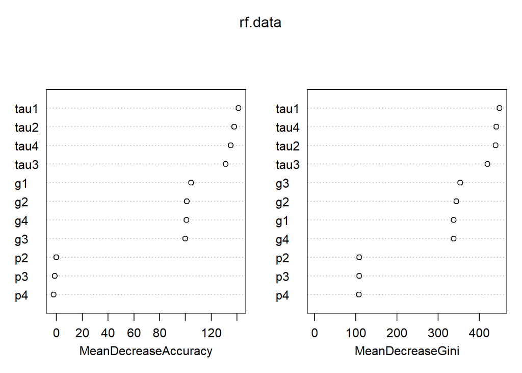

```r
varImpPlot(rf.data)
```

The above plots shows meanDecreaseAccuracy and meanDecreasedGini is the most important variables. ##Boosting The gbm package willbe used here where gbm()function will be used.

```r
#install.packages('gbm')
library(gbm)
set.seed(1)
data = read.csv("electricity19.csv")
data$stabf = as.numeric(data$stabf)
data = transform(data,stabf=stabf-1)
train=sample(1:nrow(data),7500)
data.test = data[-train,]
stabf.test = data$stabf[-train]

boost.data=gbm(stabf~.,data[train,],distribution = "bernoulli",n.trees = 5000, interaction.depth = 4)
```

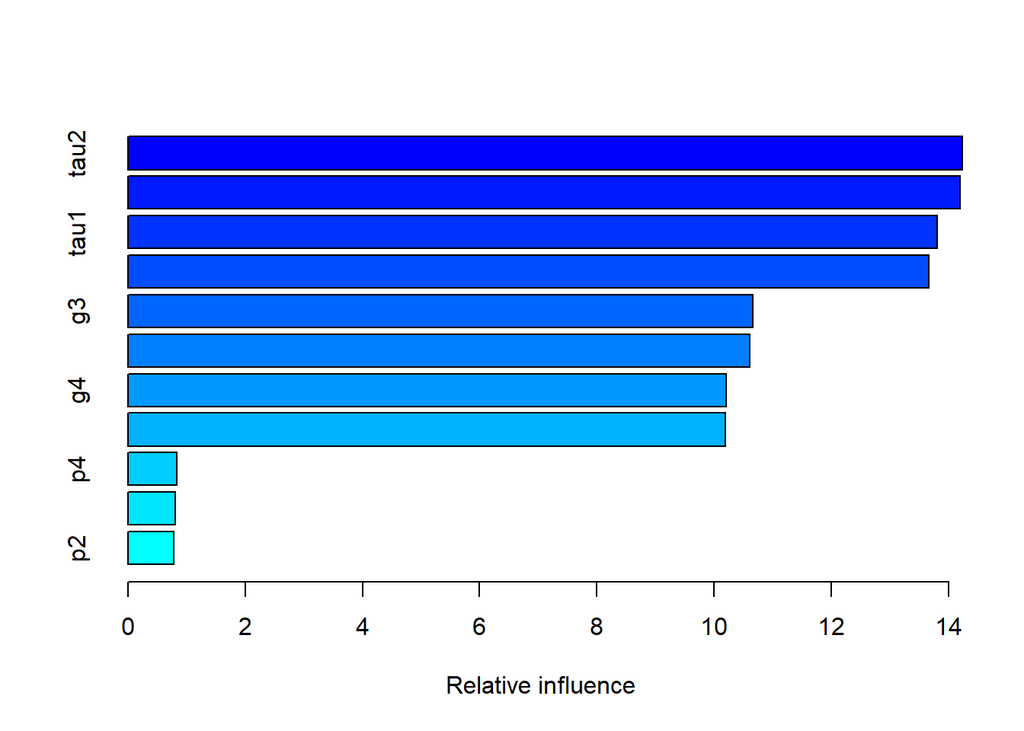

```
##       var    rel.inf
## tau2 tau2 14.2353048
## tau4 tau4 14.2032276
## tau1 tau1 13.8088269
## tau3 tau3 13.6710992
## g3     g3 10.6593969
## g2     g2 10.6094066
## g4     g4 10.2077342
## g1     g1 10.1954886
## p4     p4  0.8329761
## p3     p3  0.8010815
## p2     p2  0.7754576
```

```r
summary(boost.data)
```

From above procedure, tau2 and tau4 are the most important variables. tau1, tau3,g3,g4 and g1 are also imporatnt variables.

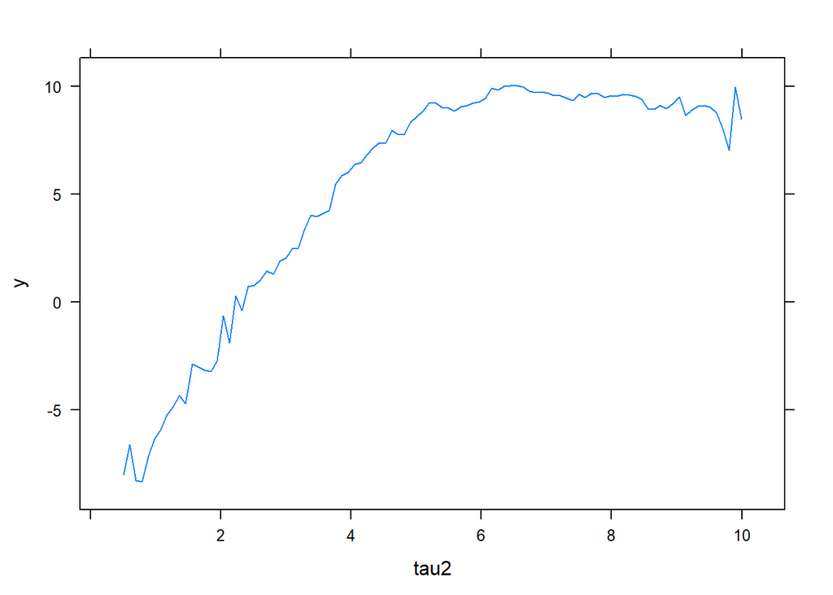

```r
par(mfrow=c(1,2))
plot(boost.data,i='tau2')
```

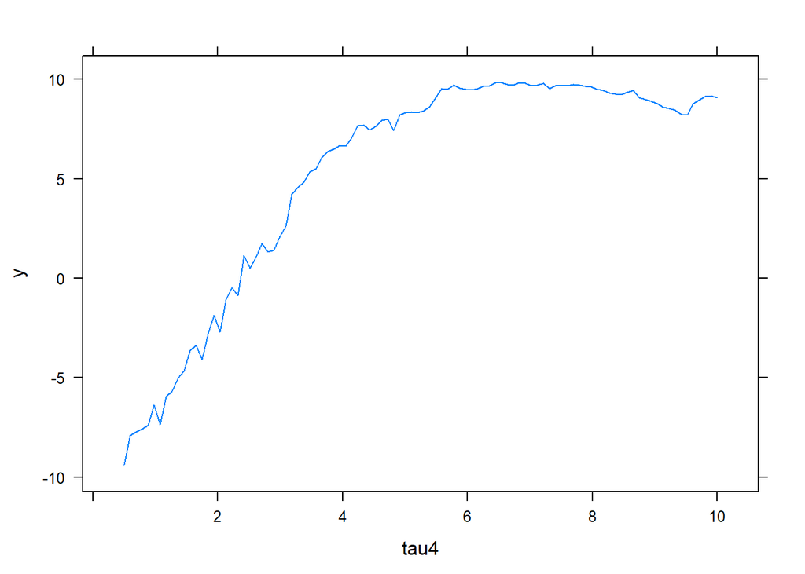

```r
plot(boost.data,i='tau4')
```

In the above procedure, I produced partial dependence plots for the two most important variables. These ilustrate the marginal effect of the selected variables on the response after integrating out the other variable.

I will now use the boosted model to predict stabf on the test set.

```r
yhat.boost=predict(boost.data,data.test,type = "response",n.trees = 5000)
mean(yhat.boost==stabf.test)
```

```
## [1] 4e-04
```

```r
#table(yhat.boost,stabf.test)
```

In the above procedure we used the default lambda which is 0.1. I will run the procedure again to make use of lambda as 0.2.

```r
boost.data=gbm(stabf~.,data[train,],distribution = "bernoulli",n.trees = 5000, interaction.depth = 4, shrinkage = 0.2, verbose = F)
yhat.boost=predict(boost.data,data.test,type = "response",n.trees = 5000)
mean(yhat.boost==stabf.test)
```

```
## [1] 0.1248
```